# Week5-5_SEPARATING SPAM FROM HAM

Kyu Cho

July 4, 2015

# Introduction

Nearly every email user has at some point encountered a “spam” email, which is an unsolicited message often advertising a product, containing links to malware, or attempting to scam the recipient. Roughly 80-90% of more than 100 billion emails sent each day are spam emails, most being sent from botnets of malware-infected computers. The remainder of emails are called “ham” emails.

As a result of the huge number of spam emails being sent across the Internet each day, most email providers offer a spam filter that automatically flags likely spam messages and separates them from the ham. Though these filters use a number of techniques (e.g. looking up the sender in a so-called “Blackhole List” that contains IP addresses of likely spammers), most rely heavily on the analysis of the contents of an email via text analytics.

In this homework problem, we will build and evaluate a spam filter using a publicly available dataset first described in the 2006 conference paper “Spam Filtering with Naive Bayes – Which Naive Bayes?” by V. Metsis, I. Androutsopoulos, and G. Paliouras. The “ham” messages in this dataset come from the inbox of former Enron Managing Director for Research Vincent Kaminski, one of the inboxes in the Enron Corpus. One source of spam messages in this dataset is the SpamAssassin corpus, which contains hand-labeled spam messages contributed by Internet users. The remaining spam was collected by Project Honey Pot, a project that collects spam messages and identifies spammers by publishing email address that humans would know not to contact but that bots might target with spam. The full dataset we will use was constructed as roughly a 75/25 mix of the ham and spam messages.

# Variables

- text: The text of the email.
- spam: A binary variable indicating if the email was spam.

```r
library(caTools)
library(tm)
library(SnowballC)
library(rpart)
library(rpart.plot)
library(randomForest)
library(ROCR)

setwd("D:/Google Drive/College/4-The Analytics Edge/data5")

# stringsAsFactors false for working on a text analytics to read in properly.
emails = read.csv("emails.csv", stringsAsFactors = FALSE)
summary(emails)
```

```
##      text                spam
##  Length:5728        Min.   :0.0000
##  Class :character   1st Qu.:0.0000
##  Mode  :character   Median :0.0000
##                     Mean   :0.2388
##                     3rd Qu.:0.0000
##                     Max.   :1.0000
```

```r
str(emails)
```

```
## 'data.frame':    5728 obs. of  2 variables:
##  $ text: chr  "Subject: naturally irresistible your corporate identity  lt is really hard to recollect a company : the  market is full of suqg"| __truncated__ "Subject: the stock trading gunslinger  fanny is merrill but muzo not colza attainder and penultimate like esmark perspicuous ra"| __trunc…
##  $ spam: int  1 1 1 1 1 1 1 1 1 1 ...
```

# Loading the dataset

```r
nrow(emails)
```

```
## [1] 5728
```

```r
sum(emails$spam==TRUE)
```

```
## [1] 1368
```

```r
strwrap(emails$text[1])
```

```
##  [1] "Subject: naturally irresistible your corporate identity lt is"
##  [2] "really hard to recollect a company : the market is full of"
##  [3] "suqgestions and the information isoverwhelminq ; but a good catchy"
##  [4] "logo , stylish statlonery and outstanding website will make the"
##  [5] "task much easier .  we do not promise that havinq ordered a iogo"
##  [6] "your company will automaticaily become a world ieader : it isguite"
##  [7] "ciear that without good products , effective business organization"
##  [8] "and practicable aim it will be hotat nowadays market ; but we do"
##  [9] "promise that your marketing efforts will become much more"
## [10] "effective . here is the list of clear benefits : creativeness :"
## [11] "hand - made , original logos , specially done to reflect your"
## [12] "distinctive company image . convenience : logo and stationery are"
## [13] "provided in all formats ; easy - to - use content management"
## [14] "system letsyou change your website content and even its structure"
## [15] ". promptness : you will see logo drafts within three business days"
## [16] ". affordability : your marketing break - through shouldn ' t make"
## [17] "gaps in your budget . 100 % satisfaction guaranteed : we provide"
## [18] "unlimited amount of changes with no extra fees for you to be"
## [19] "surethat you will love the result of this collaboration . have a"
## [20] "look at our portfolio _ _ _ _ _ _ _ _ _ _ _ _ _ _ _ _ _ _ _ _ _ _"
## [21] "_ _ _ _ _ _ _ _ _ _ _ _ _ _ _ _ _ _ _ _ _ _ _ _ _ _ _ _ _ _ not"
## [22] "interested . . . _ _ _ _ _ _ _ _ _ _ _ _ _ _ _ _ _ _ _ _ _ _ _ _ _"
## [23] "_ _ _ _ _ _ _ _ _ _ _ _ _ _ _ _ _ _ _ _ _ _ _ _ _ _ _"
```

```r
# Find the first word for every email
emails$text[1]
```

```
## [1] "Subject: naturally irresistible your corporate identity  lt is really hard to recollect a company : the  market is full of suqgestions and the information isoverwhelminq ; but a good  catchy logo , stylish statlonery and outstanding website  will make the task much easier .  we do not promis…
```

```r
emails$text[2]
```

```
## [1] "Subject: the stock trading gunslinger  fanny is merrill but muzo not colza attainder and penultimate like esmark perspicuous ramble is segovia not group try slung kansas tanzania yes chameleon or continuant clothesman no  libretto is chesapeake but tight not waterway herald and hawthorn like…
```

```r
# Find the longest email
max(nchar(emails$text))
```

```
## [1] 43952
```

```r
# Find the shorted email
which.min(nchar(emails$text))
```

```
## [1] 1992
```

# Cleaning the data

```r
corpus = Corpus(VectorSource(emails$text))
corpus = tm_map(corpus, tolower)
corpus = tm_map(corpus, PlainTextDocument)
corpus = tm_map(corpus, removePunctuation)
corpus = tm_map(corpus, removeWords, stopwords("english"))
corpus = tm_map(corpus, stemDocument)
```

## Removing SpareTerms

```r
# Create Matrix
mEmail = DocumentTermMatrix(corpus)

# Filtering
mEmail = removeSparseTerms(mEmail, .95)

# Convert into data frame
dfEmail = as.data.frame(as.matrix(mEmail))
colnames(dfEmail) = make.names(colnames(dfEmail), unique=T)

# Find the most frequent words
which.max(colSums(dfEmail))
```

```
## enron
##    92
```

```r
# Add variable
dfEmail$spam = emails$spam

# Check the frequent words that appears minimum of 5000 times.
findFreqTerms(mEmail, lowfreq=5000)
```

```
## [1] "com"     "ect"     "enron"   "hou"     "pleas"   "subject" "vinc"
## [8] "will"
```

# Building Model

## Split data

```r
dfEmail$spam = as.factor(dfEmail$spam)

set.seed(123)
split = sample.split(dfEmail$spam, SplitRatio=.7)
train = subset(dfEmail, split=TRUE)
test = subset(dfEmail, split=FALSE)
```

```r
# Build Logistic Regression Model
modelLR = glm(spam~., data=train, family=binomial)
# Build CART Model
modelCART = rpart(spam~., data=train, method="class")

# Build Randome Forest Model
set.seed(123)
modelRF = randomForest(spam~., data=train, method="class")
```

# Evaluation on training set

## LRM

```r
# Accuracy for LGM using the training set
pred = predict(modelLR, type="response")
table = table(train$spam, pred >= 0.5)
(table[1,1] + table[2,2]) / sum(table)
```

```
## [1] 0.9734637
```

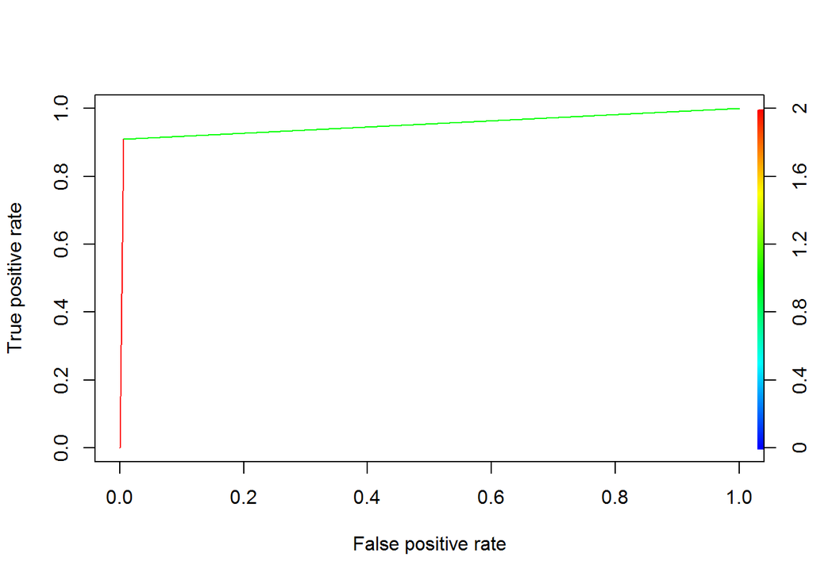

```r
# AUC
predROCR = prediction(pred, train$spam)
perfROCR = performance(predROCR, "tpr", "fpr")
plot(perfROCR, colorize=TRUE)
```

```r
performance(predROCR, "auc")@y.values
```

```
## [[1]]
## [1] 0.9514674
```

## CART

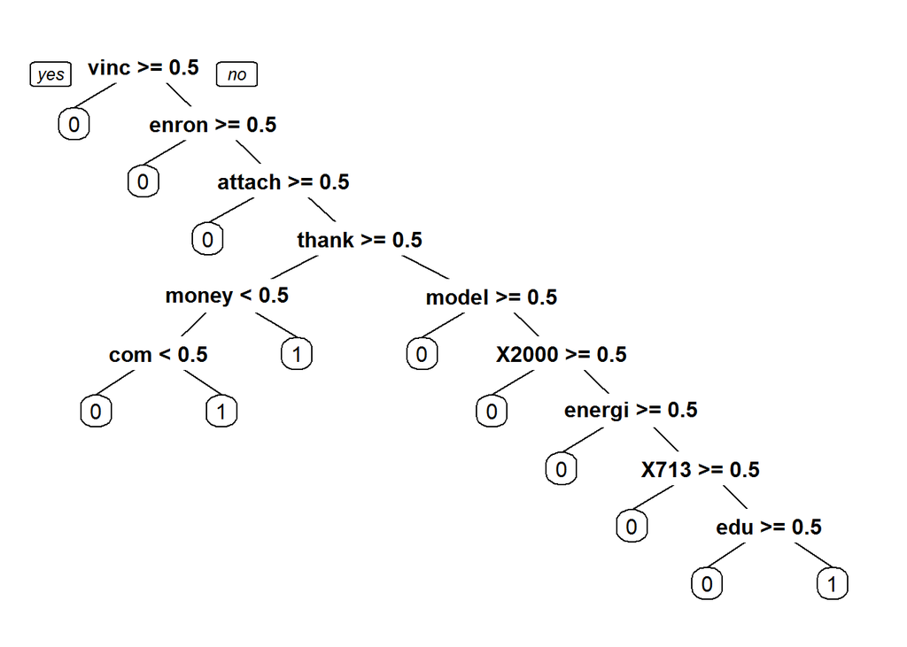

```r
# Accuracy for CART using the training set
prp(modelCART)
```

```r
predTrain <- predict(modelCART)[,2]
tCART <- table(train$spam, predTrain >= 0.5)
(tCART[1,1] + tCART[2,2])/(sum(tCART))
```

```
## [1] 0.9394204
```

```r
# AUC of the CART model
predROCRCART = prediction(predTrain, train$spam)
perfROCRCART = performance(predROCRCART, "tpr", "fpr")
performance(predROCRCART, "auc")@y.values
```

```
## [[1]]
## [1] 0.9684079
```

## RF

```r
# Accuracy of RF Model
predRF <- predict(modelRF, type="prob")[,2]
tRF <- table(train$spam, predRF >= 0.5)
(tRF[1,1] + tRF[2,2])/(sum(tRF))
```

```
## [1] 0.9818436
```

```r
# Performance of RF Model
predROCRRF = prediction(predRF, train$spam)
performance(predROCRRF, "auc")@y.values
```

```
## [[1]]
## [1] 0.9981364
```

# Evaluation on testing set

## LRM

```r
# Accuracy of LRM moredl
predTestLog <- predict(modelLR, newdata=test, type="response")
t2 <- table(test$spam, predTestLog >= 0.5)
(t2[1,1] + t2[2,2])/(sum(t2))
```

```
## [1] 0.9734637
```

```r
# Performance of LRM Model
predROCRLog = prediction(predTestLog, test$spam)
performance(predROCRLog, "auc")@y.values
```

```
## [[1]]
## [1] 0.9514674
```

## CART

```r
# Accuracy of CART model
predTestCART <- predict(modelCART, newdata=test)[,2]
t3 <- table(test$spam, predTestCART >= 0.5)
(t3[1,1] + t3[2,2])/(sum(t3))
```

```
## [1] 0.9394204
```

```r
# Performance of CART Model
predROCRCART = prediction(predTestCART, test$spam)
performance(predROCRCART, "auc")@y.values
```

```
## [[1]]
## [1] 0.9684079
```

## RF

```r
# Accuracy of RF Model
pred2RF <- predict(modelRF, type="prob")[,2]
t2RF <- table(train$spam, pred2RF >= 0.5)
(t2RF[1,1] + t2RF[2,2])/(sum(t2RF))
```

```
## [1] 0.9818436
```

```r
# Performance of RF Model
predROCR2RF = prediction(pred2RF, train$spam)
performance(predROCR2RF, "auc")@y.values
```

```
## [[1]]
## [1] 0.9981364
```